# Stochastic Reserving: Modus Operandi

### Step 10 (continued): Review the reserve development (fan) charts again after manually adjusting the variance parameters:

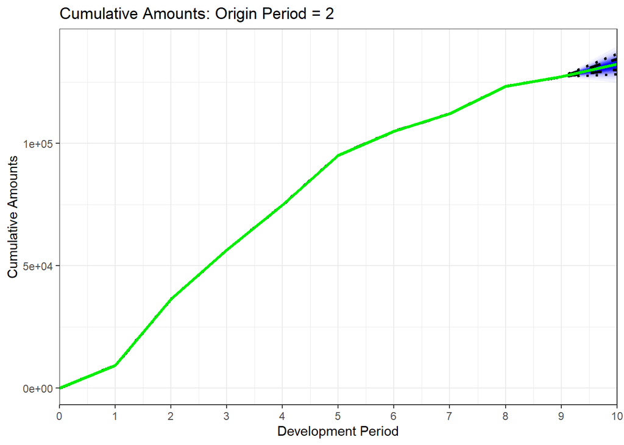

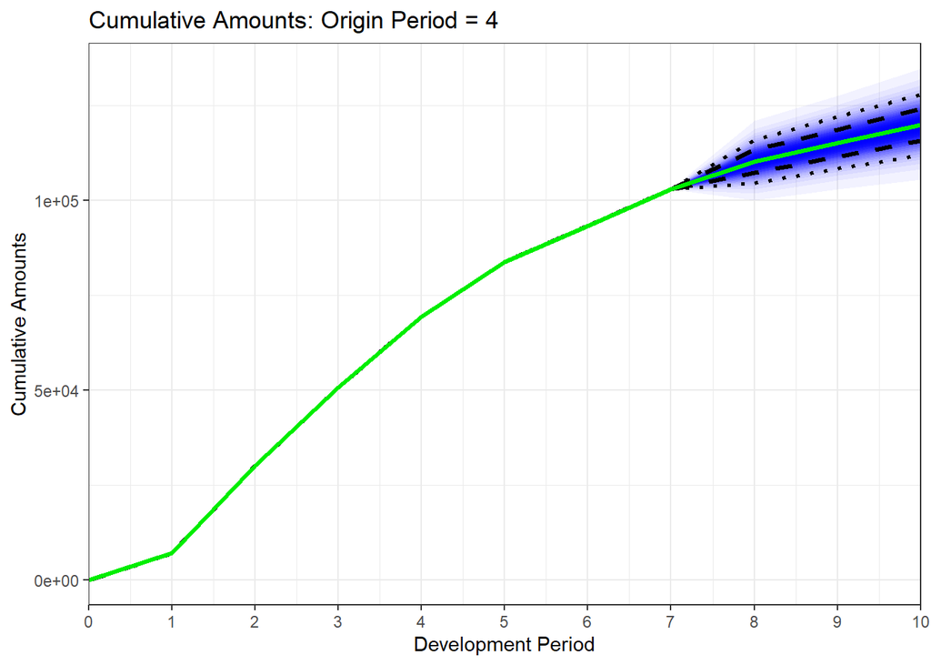

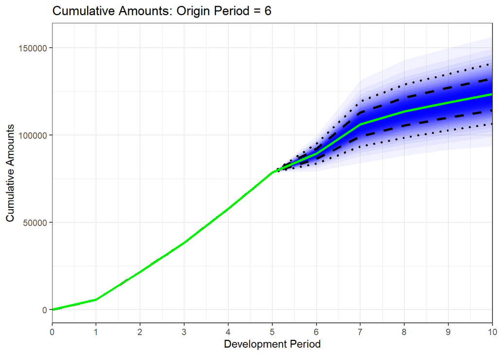

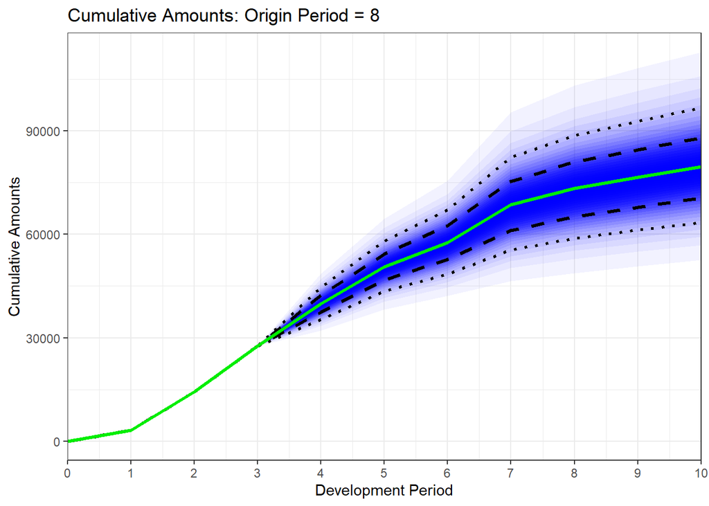

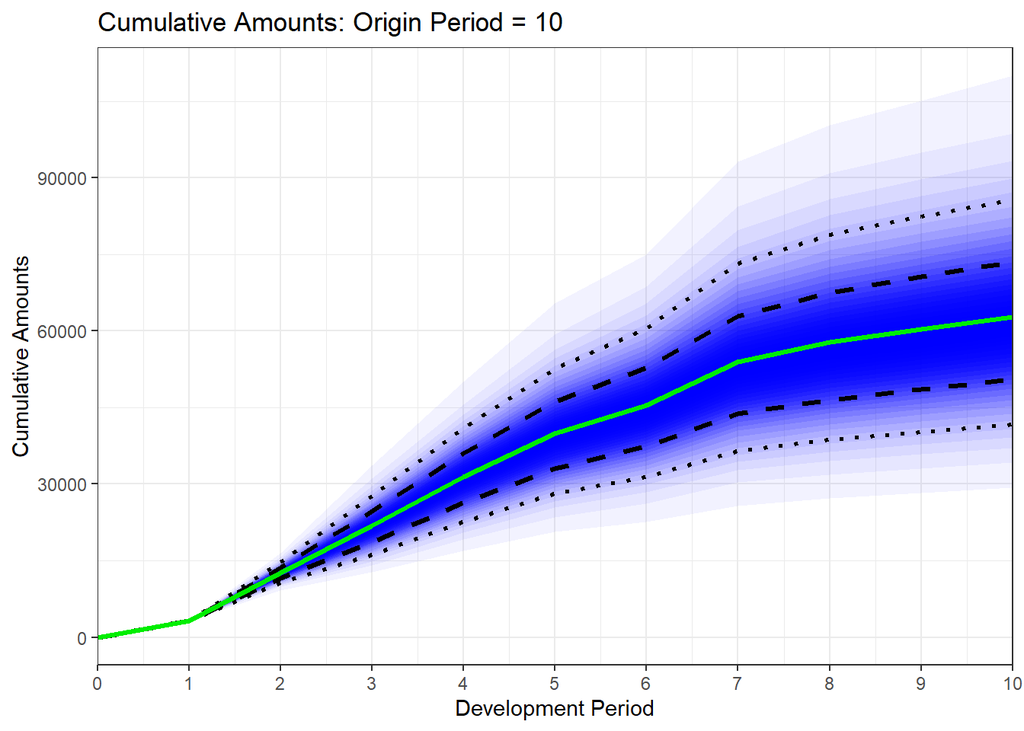

```r
BStrap_Cumulatives <- Mack_Bstrap_Result$Cumulatives

for (yr in seq(2, ncol(BStrap_Cumulatives), by = 2)) {
  print(plotDevelopmentGraph(BStrap_Cumulatives,yr))
}
```

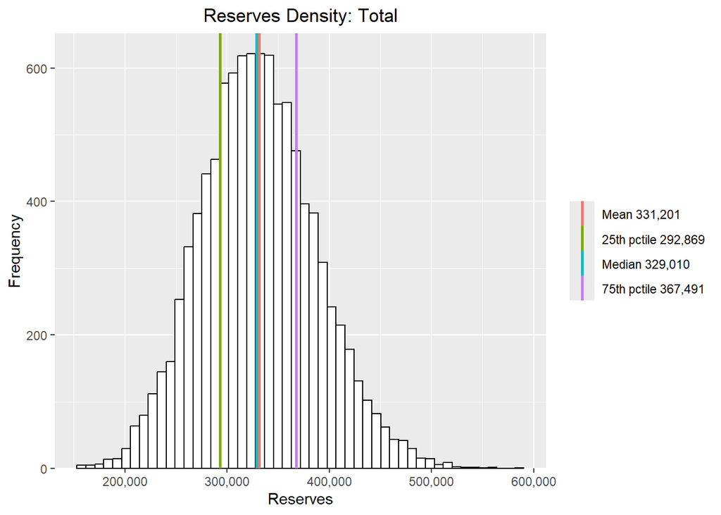

```r
# Histograms - Bootstrap undiscounted reserves
plotHistogram_Total(Mack_Bstrap_Result$TotalReserve)
```

```r
#plotHistogram_by_yr(Mack_Bstrap_Result$Reserves)
```

*Commentary:*

Notice that the reserve development (fan) charts no longer suddenly expand at development period 7 since the values of Mack’s sigma have a smoother development.

### Step 11: Investigate similar results for the ODP model with non-constant scale parameters. Review residuals and variance parameters for the ODP model:

```r
# Start with all link ratios included. There is no need to calculate the SD of the forecasts analytically (closed form),
# we can proceed straight to bootstrapping. First, look at the residuals and the square root of the scale parameters.

# Calculate residuals for the ODP model with non-constant scale parameters including all ratios:
method <- "ODPNonConstant"
Resids <- Calc_Residuals(Triangle, method=method)

# show adjusted unscaled residuals
adj_unscaled_resids <- round(Resids$adjunscaledresids,3)
dp_labels_2 <- paste("DP", 1:(length(Triangle)), sep=" ")
op_labels_2 <- paste("OP", 1:(length(Triangle)), sep=" ")
dimnames(adj_unscaled_resids) <- list(op_labels_2, dp_labels_2)
print("Adjusted scaled residuals")
```

```
## [1] "Adjusted scaled residuals"
```

```r
adj_unscaled_resids
```

```
##          DP 1    DP 2    DP 3    DP 4    DP 5    DP 6     DP 7    DP 8    DP 9 DP 10
## OP 1   16.835  11.653 -27.322  -5.712 -26.085  73.956  -49.695  21.022  25.630    NA
## OP 2   37.646  62.731   6.135 -15.683  21.565 -19.843 -100.308  44.828 -25.553    NA
## OP 3  -22.491 -24.278 -49.556  20.380 -42.363 -42.864  184.774 -58.139      NA    NA
## OP 4   16.616  45.788  27.862   2.480 -17.406 -12.796  -62.265      NA      NA    NA
## OP 5  -18.256 -28.743  24.782 -22.155  33.679   6.966       NA      NA      NA    NA
## OP 6   -8.046 -25.465 -12.188   6.576  37.446      NA       NA      NA      NA    NA
## OP 7   -3.111 -40.611  28.965  13.794      NA      NA       NA      NA      NA    NA
## OP 8  -17.448  -8.752  19.124      NA      NA      NA       NA      NA      NA    NA
## OP 9   -4.208   2.428      NA      NA      NA      NA       NA      NA      NA    NA
## OP 10      NA      NA      NA      NA      NA      NA       NA      NA      NA    NA
```

```r
# show zero-average scaled residuals
zeroavg_scaled_resids <- round(Resids$zeroavgscaledresids,3)
dp_labels_2 <- paste("DP", 1:(length(Triangle)), sep=" ")
op_labels_2 <- paste("OP", 1:(length(Triangle)), sep=" ")
dimnames(zeroavg_scaled_resids) <- list(op_labels_2, dp_labels_2)
print("Zero-average adjusted scaled residuals")
```

```
## [1] "Zero-average adjusted scaled residuals"
```

```r
zeroavg_scaled_resids
```

```
##         DP 1   DP 2   DP 3   DP 4   DP 5   DP 6   DP 7   DP 8  DP 9 DP 10
## OP 1   0.928  0.338 -1.011 -0.412 -0.852  1.847 -0.454  0.465  0.99    NA
## OP 2   2.089  1.874  0.213 -1.111  0.683 -0.511 -0.904  1.005 -1.01    NA
## OP 3  -1.267 -0.741 -1.824  1.417 -1.377 -1.089  1.632 -1.330    NA    NA
## OP 4   0.915  1.364  1.007  0.162 -0.573 -0.333 -0.566     NA    NA    NA
## OP 5  -1.030 -0.876  0.894 -1.565  1.073  0.163     NA     NA    NA    NA
## OP 6  -0.461 -0.777 -0.457  0.449  1.195     NA     NA     NA    NA    NA
## OP 7  -0.185 -1.232  1.047  0.955     NA     NA     NA     NA    NA    NA
## OP 8  -0.985 -0.275  0.687     NA     NA     NA     NA     NA    NA    NA
## OP 9  -0.247  0.061     NA     NA     NA     NA     NA     NA    NA    NA
## OP 10     NA     NA     NA     NA     NA     NA     NA     NA    NA    NA
```

```r
# Show variance parameters (Mack's sigma or ODP sqrtScale)
sqrtScale <- round(Resids$sqrtScale, 1)
names(sqrtScale) <- paste0("DP", 1:(length(Triangle)), sep=" ")
cat("ODP sqrtScale parameters:\n")
```

```
## ODP sqrtScale parameters:
```

```r
sqrtScale
```

```
##  DP1   DP2   DP3   DP4   DP5   DP6   DP7   DP8   DP9  DP10
##  17.9  33.3  27.3  14.3  31.0  39.8 112.4  44.1  25.6  25.6
```

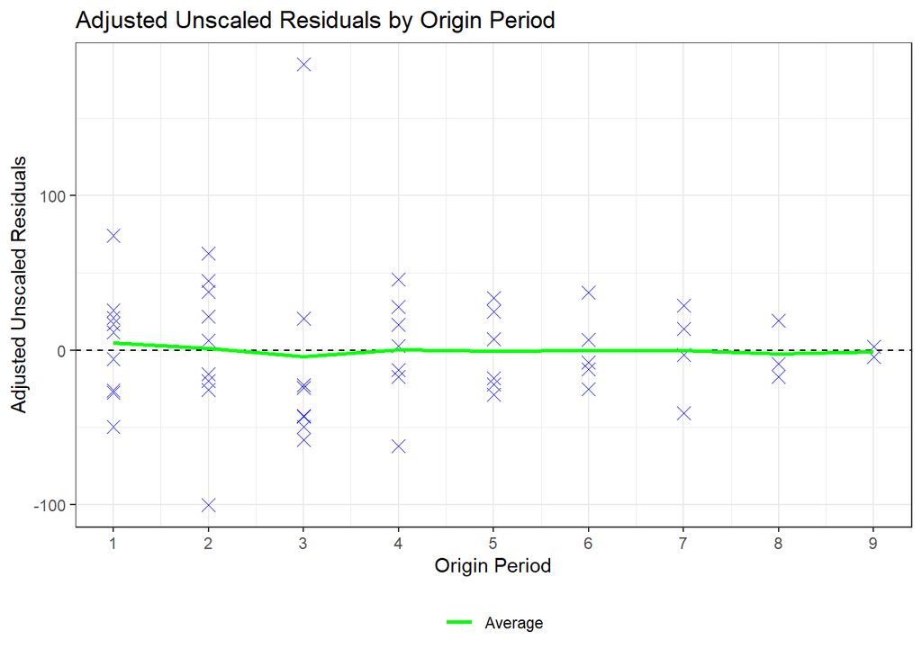

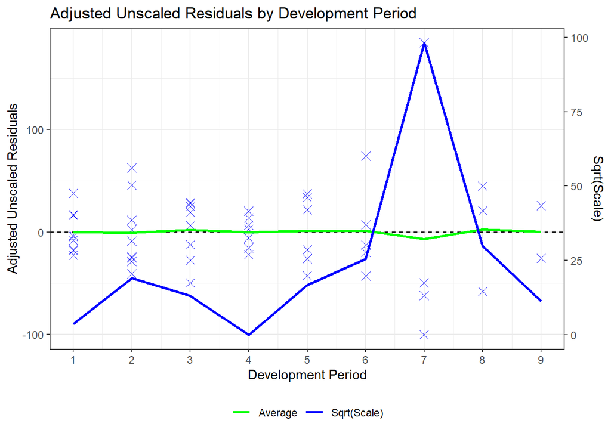

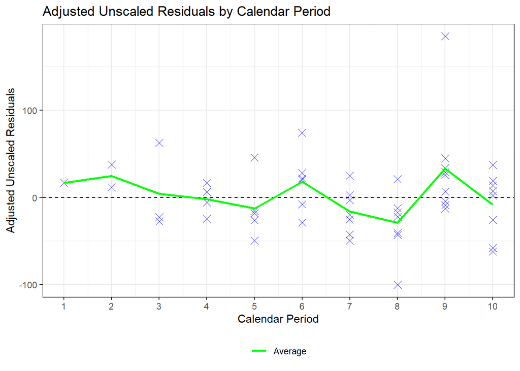

```r
sqrtScale_original <- Resids$sqrtScale # save for later

# Plot residuals
plotResiduals(Resids, resid_type="adjunscaledresids", bstrap_method=method)
```

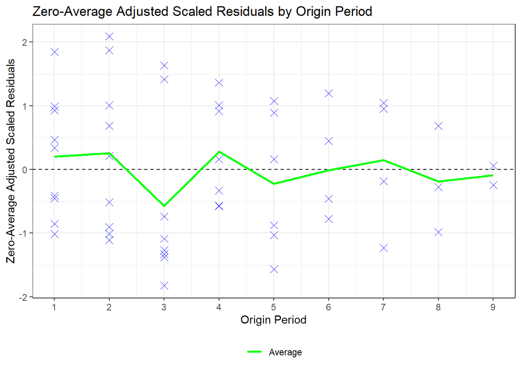

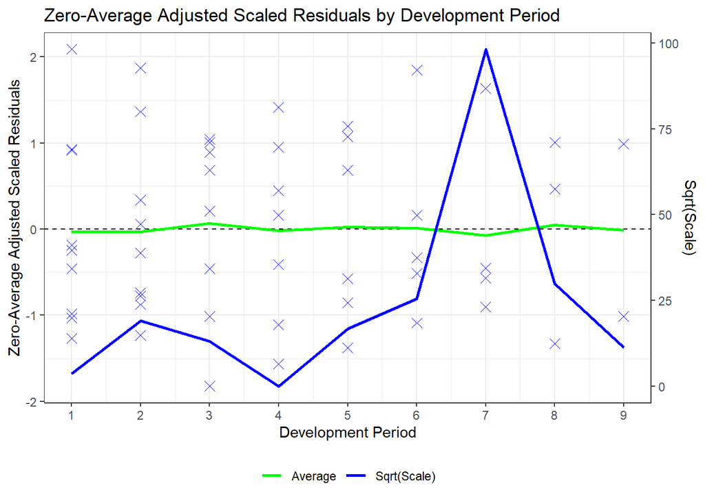

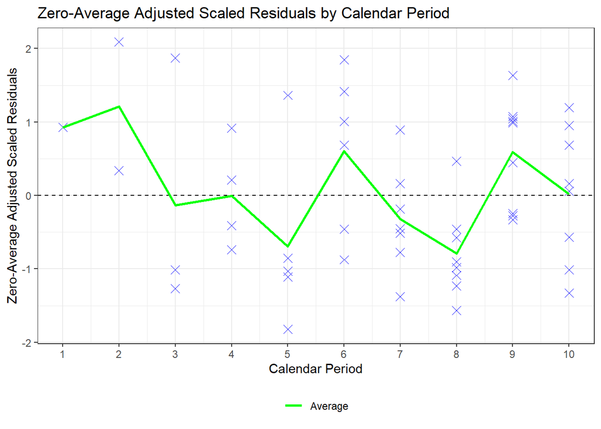

```r
plotResiduals(Resids, resid_type="zeroavgscaledresids", bstrap_method=method)
```

*Commentary:*

Using the over-dispersed Poisson (ODP) model, the inference is similar, except it is a model of the incremental amounts with a 10 by 10 triangle of residuals for this example.

When all link ratios are included, we observe a large unscaled residual at development period 7 for origin period 3 (consistent with the large incremental value at that position), which is driving the large value of the variance parameter (sqrtScale) at development period 7.

### Step 11 (continued): Bootstrap the over-dispersed Poisson model (ODP) with non-constant scale parameters, review summary statistics and compare with Mack’s model results:

```r
UserSqrtScale <- NULL # do not use user-defined scale parameters initially

ODP_Bstrap_Result <- Run_Bootstrap(Triangle, method=method,
                               replications=replications, seed=seed, BootstrapDist=BootstrapDist,
                               ForecastDist=ForecastDist, UserSqrtScale=UserSqrtScale)

#Table of results
Table_3 <- cbind(round(ODP_Bstrap_Result$Latest,0), round(ODP_Bstrap_Result$Avg_Reserve,0),
                 round(ODP_Bstrap_Result$Latest+ODP_Bstrap_Result$Avg_Reserve,0),
                 round(ODP_Bstrap_Result$SD_Reserve,0), round(100*ODP_Bstrap_Result$CoV_Reserve,1))
Table_3_Totals <- cbind(round(sum(ODP_Bstrap_Result$Latest),0), round(ODP_Bstrap_Result$Avg_TotalReserve,0),
                        round(sum(ODP_Bstrap_Result$Latest)+ODP_Bstrap_Result$Avg_TotalReserve,0),
                        round(ODP_Bstrap_Result$SD_TotalReserve,0), round(100*ODP_Bstrap_Result$CoV_TotalReserve,1))
Table_3 <- rbind(Table_3, Table_3_Totals)
dimnames(Table_3) <- list(c(1:length(Triangle), "Total"), c("Latest", "Avg Reserves",
                                                            "Avg Ultimates", "Bstrap SD", "Reserves CoV %"))
names(dimnames(Table_3)) <- c("Year","Simulated (Undiscounted)")
Table_3
```

```
##        Simulated (Undiscounted)
## Year    Latest Avg Reserves Avg Ultimates Bstrap SD Reserves CoV %
##   1     131590            0        131590         0            0.0
##   2     127208         5246        132454      2868           54.7
##   3     155978        13682        169660      4791           35.0
##   4     102958        17007        119965      6150           36.2
##   5      90853        34857        125710     17596           50.5
##   6      78429        44962        123391     18437           41.0
##   7      43554        43598         87152     16109           36.9
##   8      27644        52449         80093     17534           33.4
##   9      15327        61390         76717     21319           34.7
##   10      3157        59691         62848     23799           39.9
##   Total 776698       332880       1109578     60649           18.2
```

```r
# Show set of summary statistics
ShowStats <- ShowSummaryStats(ODP_Bstrap_Result, Output="Reserves")
```

```
## [1] "Simulation Summary Statistics - Reserves"
##                              OP.1  OP.2  OP.3  OP.4   OP.5   OP.6   OP.7   OP.8   OP.9  OP.10  Total
## Mean                            0  5246 13682 17007  34857  44962  43598  52449  61390  59691 332880
## Standard Deviation              0  2868  4791  6150  17596  18437  16109  17534  21319  23799  60649
## Coefficient of Variation (%)  0.0  54.7  35.0  36.2   50.5   41.0   36.9   33.4   34.7   39.9   18.2
## Minimum                         0    44  1886  2560   5003  12166  12887  11748  14654   6406 178159
## 0.5th Percentile                0   601  4360  5138   9406  16218  17627  22509  23157  17580 209906
## 1st Percentile                  0   838  5056  5870  10724  17792  18954  24694  25549  19959 219886
## 5th Percentile                  0  1502  6936  8322  14573  22590  23923  29769  32936  27776 244929
## 10th Percentile                 0  2032  8075  9839  17037  25698  26933  33269  37664  32720 260422
## 25th Percentile                 0  3158 10232 12531  22460  32079  32574  40077  46402  42460 289976
## 50th Percentile (Median)        0  4730 13128 16279  30652  41234  40490  49511  57913  56108 326544
## 75th Percentile                 0  6838 16494 20646  43143  53850  51202  61354  72863  73150 368894
## 90th Percentile                 0  9040 20030 25212  57913  69052  63859  74730  89289  91135 413150
## 95th Percentile                 0 10692 22458 28295  68551  80042  73634  84802 101007 103837 442361
## 99th Percentile                 0 13831 26910 34027  92602 105317  98254 108918 125624 131518 502459
## 99.5th Percentile               0 15387 30157 36885 104986 113792 109168 118548 138072 144093 525545
## Maximum                         0 24371 52456 50121 158661 225821 206970 163760 198732 201357 656350
```

```r
ShowStats <- ShowSummaryStats(ODP_Bstrap_Result, Output="Ultimates")
```

```
## [1] "Simulation Summary Statistics - Ultimates"
##                                OP.1   OP.2   OP.3   OP.4   OP.5   OP.6   OP.7   OP.8   OP.9  OP.10   Total
## Mean                         131590 132454 169660 119965 125710 123391  87152  80093  76717  62848 1109578
## Standard Deviation                0   2868   4791   6150  17596  18437  16109  17534  21319  23799   60649
## Coefficient of Variation (%)    0.0    2.2    2.8    5.1   14.0   14.9   18.5   21.9   27.8   37.9     5.5
## Minimum                      131590 127252 157864 105518  95856  90595  56441  39392  29981   9563  954857
## 0.5th Percentile             131590 127809 160338 108096 100259  94647  61181  50153  38484  20737  986604
## 1st Percentile               131590 128046 161034 108828 101577  96221  62508  52338  40876  23116  996584
## 5th Percentile               131590 128710 162914 111280 105426 101019  67477  57413  48263  30933 1021627
## 10th Percentile              131590 129240 164053 112797 107890 104127  70487  60913  52991  35877 1037120
## 25th Percentile              131590 130366 166210 115489 113313 110508  76128  67721  61729  45617 1066674
## 50th Percentile (Median)     131590 131938 169106 119237 121505 119663  84044  77155  73240  59265 1103242
## 75th Percentile              131590 134046 172472 123604 133996 132279  94756  88998  88190  76307 1145592
## 90th Percentile              131590 136248 176008 128170 148766 147481 107413 102374 104616  94292 1189848
## 95th Percentile              131590 137900 178436 131253 159404 158471 117188 112446 116334 106994 1219059
## 99th Percentile              131590 141039 182888 136985 183455 183746 141808 136562 140951 134675 1279157
## 99.5th Percentile            131590 142595 186135 139843 195839 192221 152722 146192 153399 147250 1302243
## Maximum                      131590 151579 208434 153079 249514 304250 250524 191404 214059 204514 1433048
```

*Commentary:*

Notice that when using non-constant scale parameters (where sqrtScale is calculated at each development period rather than being constant across all development periods), the standard deviation of total reserves for Mack’s model and the ODP model are close (as we might expect).

However, note that when bootstrapping the ODP model (with the parametric bootstrapping options for “BootstrapDist”), the minimum values of the reserves are positive at all origin periods when all observed incremental values are positive.

### Step 11 (continued): Review the reserve development (fan) charts for the ODP model:

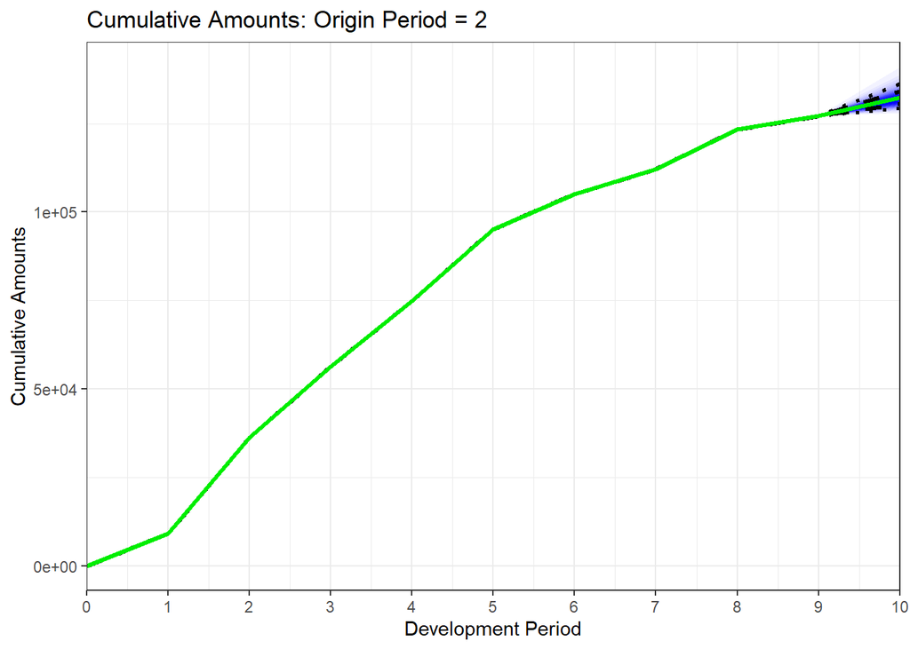

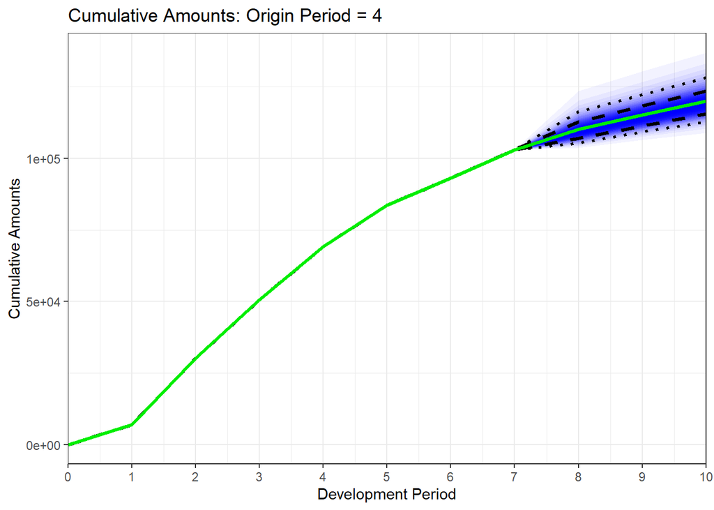

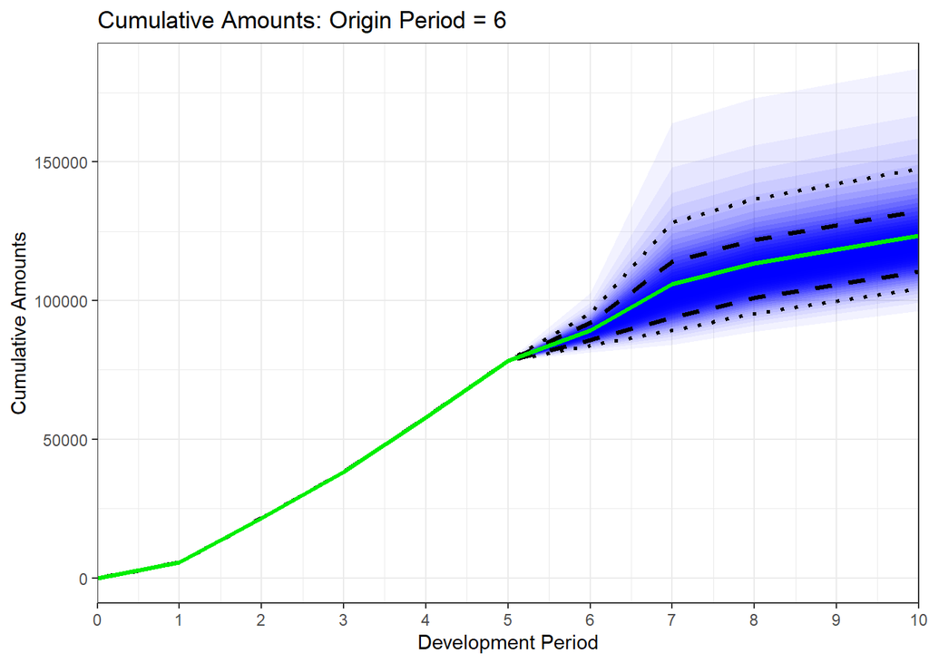

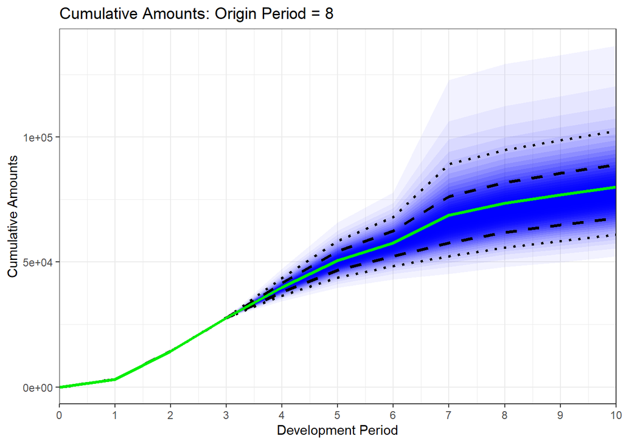

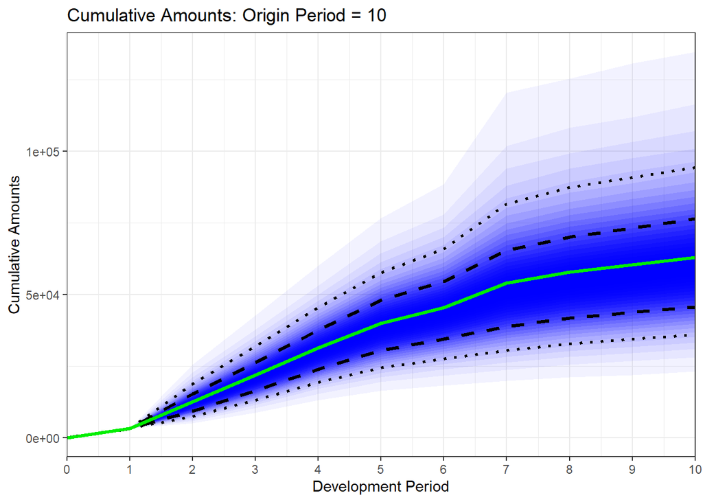

```r
BStrap_Cumulatives <- ODP_Bstrap_Result$Cumulatives

for (yr in seq(2, ncol(BStrap_Cumulatives), by = 2)) {
  print(plotDevelopmentGraph(BStrap_Cumulatives,yr))
}
```

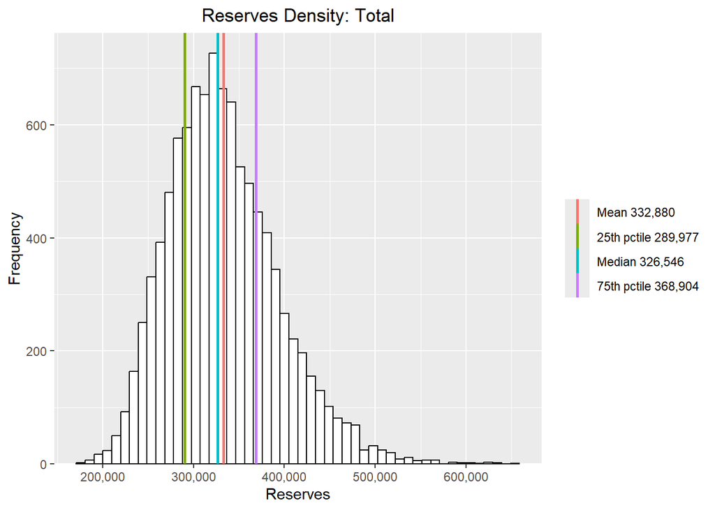

```r
# Histograms - Bootstrap undiscounted reserves
plotHistogram_Total(ODP_Bstrap_Result$TotalReserve)
```

```r
#plotHistogram_by_yr(ODP_Bstrap_Result$Reserves)
```

*Commentary:*

1. For the older origin periods, unlike Mack’s model, the cumulative amounts do not reduce for some simulations when using the ODP model. This is because the ODP model is a model of incremental amounts, and if the forecasts are simulated from a parametric distribution (using ForecastDist=Gamma or Lognormal), the forecast incremental amounts must be positive.
2. Like Mack’s model when all link ratios are included, the fan charts suddenly expand at development period 7. This is a direct result of the large value of sqrtScale observed at development period 7.

### Step 12: Investigate the impact of influential link ratios on the residuals and variance parameters for the ODP model:

```r
# The ODP model will be influenced by the same link ratios as Mack's model, so we can use the results of the sensitivity analysis
# performed above.
#
# Repeat the analysis using the ODP model, excluding the top 3 influential ratios associated with Total Reserve SDs
#
# Residuals for the ODP model excluding the top 3 influential ratios on Total Reserve SDs:

Resids <- Calc_Residuals(Triangle, method=method, Mask=Masktmp)

# show adjusted unscaled residuals
adj_unscaled_resids <- round(Resids$adjunscaledresids,3)
dp_labels_2 <- paste("DP", 1:(length(Triangle)), sep=" ")
op_labels_2 <- paste("OP", 1:(length(Triangle)), sep=" ")
dimnames(adj_unscaled_resids) <- list(op_labels_2, dp_labels_2)
print("Adjusted scaled residuals")
```

```
## [1] "Adjusted scaled residuals"
```

```r
adj_unscaled_resids
```

```
##          DP 1    DP 2    DP 3    DP 4    DP 5    DP 6    DP 7    DP 8    DP 9 DP 10
## OP 1    8.989  -1.577 -39.525 -18.681 -37.837      NA  30.970 -10.582  26.029    NA
## OP 2   29.341  48.389  -6.810 -28.482   8.775  -9.896 -37.375  10.551 -25.952    NA
## OP 3  -30.521 -38.505 -63.017   5.097 -55.433 -32.793      NA      NA      NA    NA
## OP 4    6.878  28.376  11.267 -13.702 -31.994  -5.577   6.759      NA      NA    NA
## OP 5  -20.135 -31.980  21.950 -25.373  31.018  25.750      NA      NA      NA    NA
## OP 6   -8.171 -25.861 -12.378   6.679  38.030      NA      NA      NA      NA    NA
## OP 7   -3.159 -41.244  29.416  14.008      NA      NA      NA      NA      NA    NA
## OP 8  -17.720  -8.888  19.422      NA      NA      NA      NA      NA      NA    NA
## OP 9   -4.274   2.466      NA      NA      NA      NA      NA      NA      NA    NA
## OP 10      NA      NA      NA      NA      NA      NA      NA      NA      NA    NA
```

```r
# show zero-average scaled residuals
zeroavg_scaled_resids <- round(Resids$zeroavgscaledresids,3)
dp_labels_2 <- paste("DP", 1:(length(Triangle)), sep=" ")
op_labels_2 <- paste("OP", 1:(length(Triangle)), sep=" ")
dimnames(zeroavg_scaled_resids) <- list(op_labels_2, dp_labels_2)
print("Zero-average adjusted scaled residuals")
```

```
## [1] "Zero-average adjusted scaled residuals"
```

```r
zeroavg_scaled_resids
```

```
##         DP 1   DP 2   DP 3   DP 4   DP 5   DP 6   DP 7   DP 8   DP 9 DP 10
## OP 1   0.776  0.180 -1.051 -0.808 -0.803     NA  1.327 -0.769  1.234    NA
## OP 2   2.007  1.844  0.011 -1.353  0.472 -0.226 -1.089  1.231 -0.766    NA
## OP 3  -1.613 -1.050 -1.814  0.516 -1.284 -1.285     NA     NA     NA    NA
## OP 4   0.648  1.178  0.598 -0.530 -0.643 -0.026  0.471     NA     NA    NA
## OP 5  -0.985 -0.833  0.945 -1.180  1.081  1.424     NA     NA     NA    NA
## OP 6  -0.262 -0.629 -0.170  0.604  1.273     NA     NA     NA     NA    NA
## OP 7   0.041 -1.142  1.188  1.012     NA     NA     NA     NA     NA    NA
## OP 8  -0.839 -0.064  0.863     NA     NA     NA     NA     NA     NA    NA
## OP 9  -0.026  0.315     NA     NA     NA     NA     NA     NA     NA    NA
## OP 10     NA     NA     NA     NA     NA     NA     NA     NA     NA    NA
```

```r
# Show variance parameters (Mack's sigma or ODP sqrtScale)
sqrtScale <- round(Resids$sqrtScale, 1)
names(sqrtScale) <- paste0("DP", 1:(length(Triangle)), sep=" ")
cat("ODP sqrtScale parameters:\n")
```

```
## ODP sqrtScale parameters:
```

```r
sqrtScale
```

[output not shown]

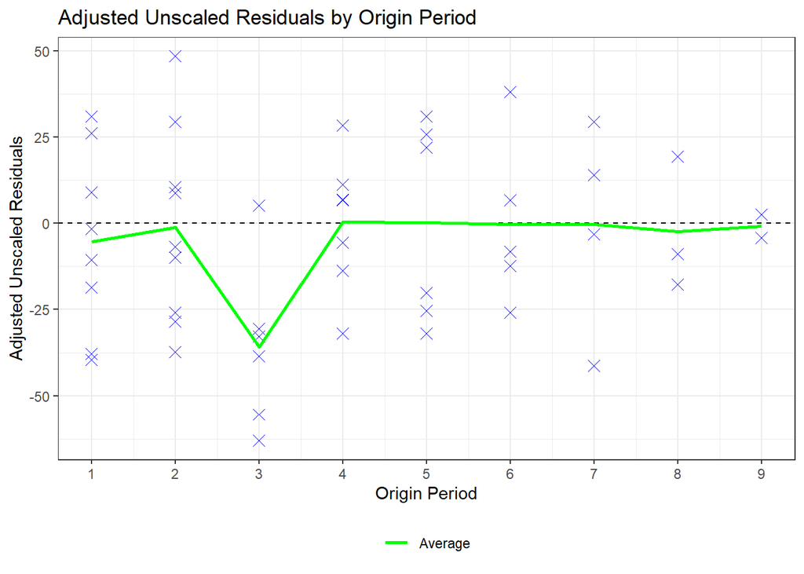

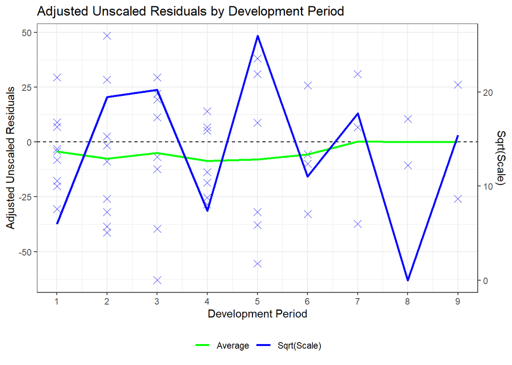

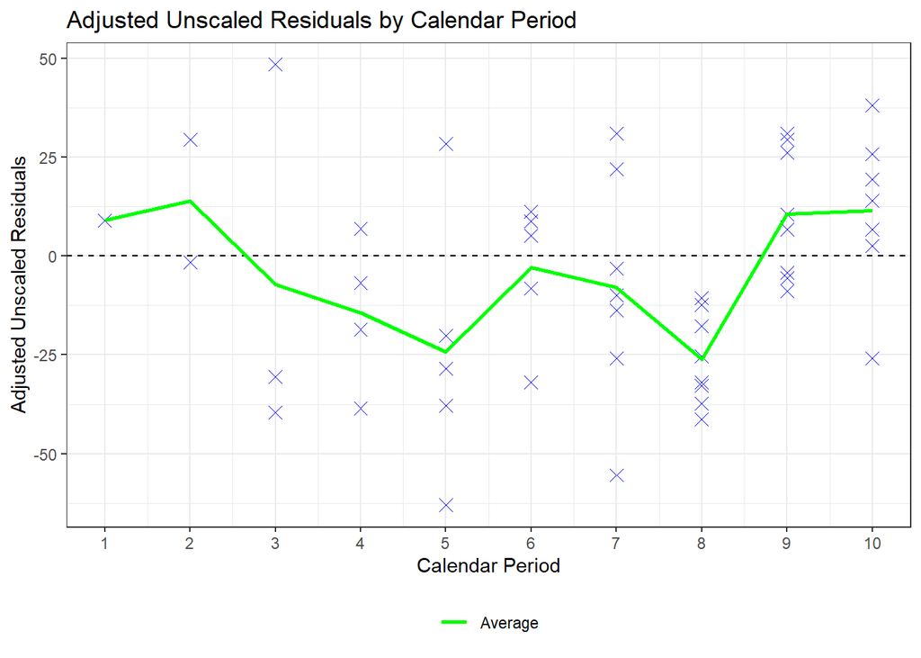

```r
# Plot residuals
plotResiduals(Resids, resid_type="adjunscaledresids", bstrap_method=method)
```

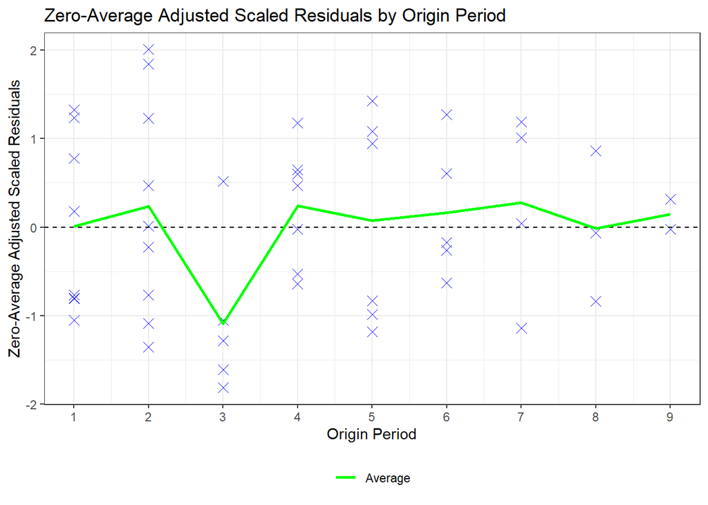

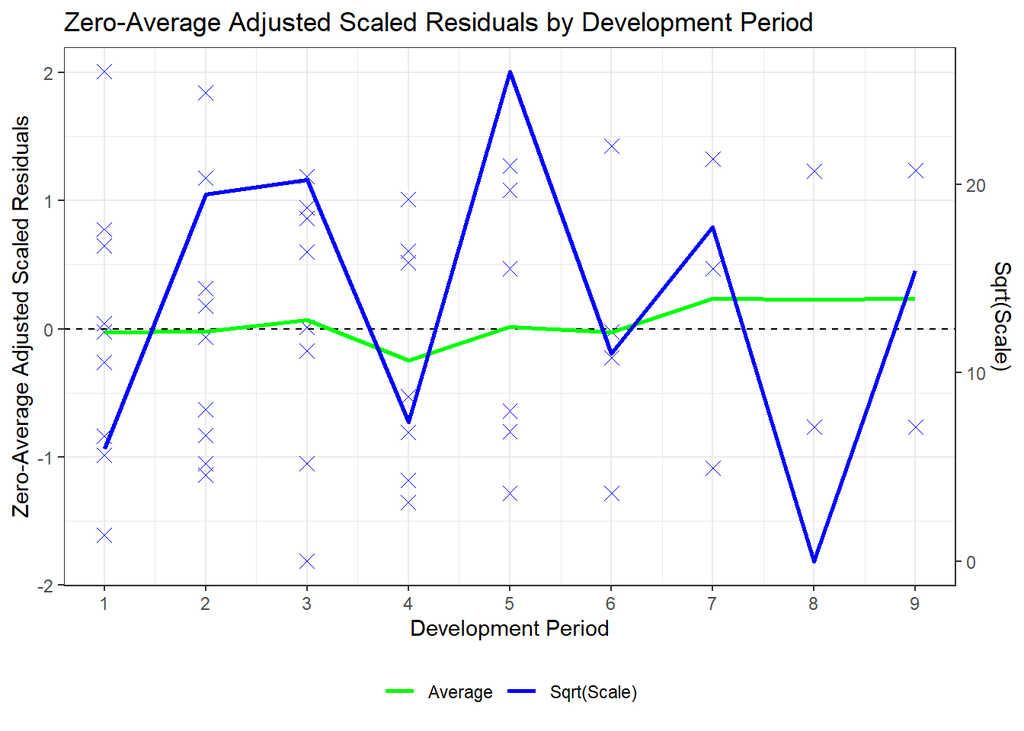

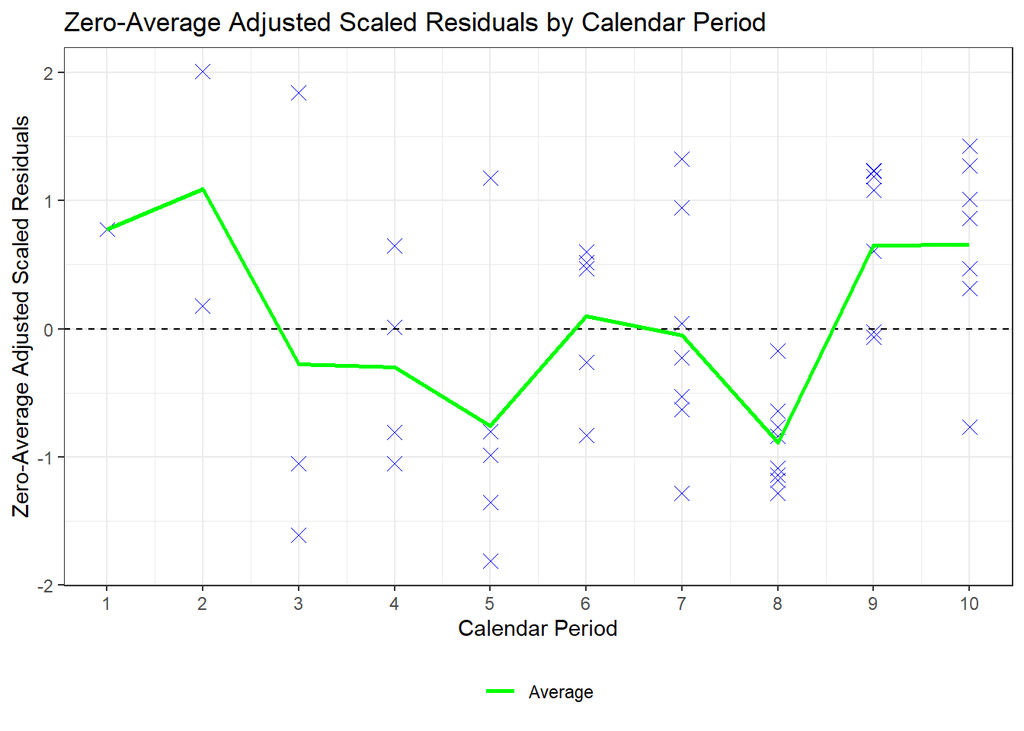

```r
plotResiduals(Resids, resid_type="zeroavgscaledresids", bstrap_method=method)
```

*Commentary:*

Excluding the most influential link ratios identified from the sensitivity analysis above for Mack’s model also excludes the associated residuals for the ODP model, which has a follow-on impact on the calculation of the parameters in the variance (sqrtScale).

By convention, if link ratios between development periods 1-2 are excluded, then both ODP residuals at development periods 1 and 2 are excluded, otherwise just exclude the residual associated with the position of the numerator of the link ratio.

Excluding the link ratio at development period 6 for origin period 3 excludes the ODP residual at development period 7, which dramatically reduces sqrtScale at development period 7. This, in turn, will reduce the standard deviation of the reserves significantly.

### Step 12 (continued): Re-apply the bootstrap method using the ODP model after excluding the most influential ratios:

```r
ODP_Bstrap_Result <- Run_Bootstrap(Triangle, Mask=Masktmp, method=method,
                               replications=replications, seed=seed, BootstrapDist=BootstrapDist,
                               ForecastDist=ForecastDist, UserSqrtScale=UserSqrtScale)

#Table of results
Table_3 <- cbind(round(ODP_Bstrap_Result$Latest,0), round(ODP_Bstrap_Result$Avg_Reserve,0),
                 round(ODP_Bstrap_Result$Latest+ODP_Bstrap_Result$Avg_Reserve,0),
                 round(ODP_Bstrap_Result$SD_Reserve,0), round(100*ODP_Bstrap_Result$CoV_Reserve,1))
Table_3_Totals <- cbind(round(sum(ODP_Bstrap_Result$Latest),0), round(ODP_Bstrap_Result$Avg_TotalReserve,0),
                        round(sum(ODP_Bstrap_Result$Latest)+ODP_Bstrap_Result$Avg_TotalReserve,0),
                        round(ODP_Bstrap_Result$SD_TotalReserve,0), round(100*ODP_Bstrap_Result$CoV_TotalReserve,1))
Table_3 <- rbind(Table_3, Table_3_Totals)
dimnames(Table_3) <- list(c(1:length(Triangle), "Total"), c("Latest", "Avg Reserves",
                                                            "Avg Ultimates", "Bstrap SD", "Reserves CoV %"))
names(dimnames(Table_3)) <- c("Year","Simulated (Undiscounted)")
Table_3
```

```
##        Simulated (Undiscounted)
## Year    Latest Avg Reserves Avg Ultimates Bstrap SD Reserves CoV %
##   1     131590            0        131590         0            0.0
##   2     127208         5202        132410      1215           23.4
##   3     155978        13591        169569      3305           24.3
##   4     102958        19493        122451      3447           17.7
##   5      90853        27954        118807      5070           18.1
##   6      78429        36286        114715      6195           17.1
##   7      43554        37459         81013      7552           20.2
##   8      27644        46571         74215     10323           22.2
##   9      15327        55609         70936     14307           25.7
##   10      3157        55719         58876     17928           32.2
##   Total 776698       297885       1074583     32725           11.0
```

```r
# Show set of summary statistics
ShowStats <- ShowSummaryStats(ODP_Bstrap_Result, Output="Reserves")
```

```
## [1] "Simulation Summary Statistics - Reserves"
##                              OP.1  OP.2  OP.3  OP.4  OP.5  OP.6  OP.7  OP.8   OP.9  OP.10  Total
## Mean                            0  5202 13591 19493 27954 36286 37459 46571  55609  55719 297885
## Standard Deviation              0  1215  3305  3447  5070  6195  7552 10323  14307  17928  32725
## Coefficient of Variation (%)  0.0  23.4  24.3  17.7  18.1  17.1  20.2  22.2   25.7   32.2   11.0
## Minimum                         0  1630  4338  9525 13721 18714 14926 17052  13538   9377 193284
## 0.5th Percentile                0  2632  6704 12079 16790 22263 21089 24084  25146  20860 223874
## 1st Percentile                  0  2790  7211 12537 17677 23633 22327 25784  27796  22547 229137
## 5th Percentile                  0  3374  8769 14218 20278 26867 25972 31181  34707  29698 247087
## 10th Percentile                 0  3705  9589 15263 21716 28675 28182 33998  38529  34075 257483
## 25th Percentile                 0  4338 11190 17079 24387 31925 32045 39280  45238  42902 274478
## 50th Percentile (Median)        0  5113 13314 19274 27616 35911 36998 45762  54387  53975 296560
## 75th Percentile                 0  5970 15667 21590 31157 40171 42183 53144  64303  66482 318956
## 90th Percentile                 0  6786 17993 24038 34583 44423 47229 60320  74786  79780 340499
## 95th Percentile                 0  7335 19471 25622 36800 47015 50675 64615  81020  88452 352978
## 99th Percentile                 0  8374 22525 28585 41409 52393 57386 73801  94666 105329 382028
## 99.5th Percentile               0  8671 23728 29889 43204 54630 59697 76948  99701 110976 393036
## Maximum                         0 10824 29580 38502 52968 64517 83029 95349 130763 147168 445189
```

```r
ShowStats <- ShowSummaryStats(ODP_Bstrap_Result, Output="Ultimates")
```

```
## [1] "Simulation Summary Statistics - Ultimates"
##                                OP.1   OP.2   OP.3   OP.4   OP.5   OP.6   OP.7   OP.8   OP.9  OP.10   Total
## Mean                         131590 132410 169569 122451 118807 114715  81013  74215  70936  58876 1074583
## Standard Deviation                0   1215   3305   3447   5070   6195   7552  10323  14307  17928   32725
## Coefficient of Variation (%)    0.0    0.9    1.9    2.8    4.3    5.4    9.3   13.9   20.2   30.5     3.0
## Minimum                      131590 128838 160316 112483 104574  97143  58480  44696  28865  12534  969982
## 0.5th Percentile             131590 129840 162682 115037 107643 100692  64643  51728  40473  24017 1000572
## 1st Percentile               131590 129998 163189 115495 108530 102062  65881  53428  43123  25704 1005835
## 5th Percentile               131590 130582 164747 117176 111131 105296  69526  58825  50034  32855 1023785
## 10th Percentile              131590 130913 165567 118221 112569 107104  71736  61642  53856  37232 1034181
## 25th Percentile              131590 131546 167168 120037 115240 110354  75599  66924  60565  46059 1051176
## 50th Percentile (Median)     131590 132321 169292 122232 118469 114340  80552  73406  69714  57132 1073258
## 75th Percentile              131590 133178 171645 124548 122010 118600  85737  80788  79630  69639 1095654
## 90th Percentile              131590 133994 173971 126996 125436 122852  90783  87964  90113  82937 1117197
## 95th Percentile              131590 134543 175449 128580 127653 125444  94229  92259  96347  91609 1129676
## 99th Percentile              131590 135582 178503 131543 132262 130822 100940 101445 109993 108486 1158726
## 99.5th Percentile            131590 135879 179706 132847 134057 133059 103251 104592 115028 114133 1169734
## Maximum                      131590 138032 185558 141460 143821 142946 126583 122993 146090 150325 1221887
```

*Commentary:*

Bootstrapping the ODP model excluding the top 3 most influential link ratios on the standard deviation, we observe that the mean, standard deviation and coefficient of variation of the reserves in total and by origin period all reduce significantly. Note that they match closely the results from Mack’s model with the same exclusions, with the coefficient of variation of the total reserves being approximatley 10%.

### Step 12 (continued): Review the reserve development (fan) charts again after excluding the most influential ratios:

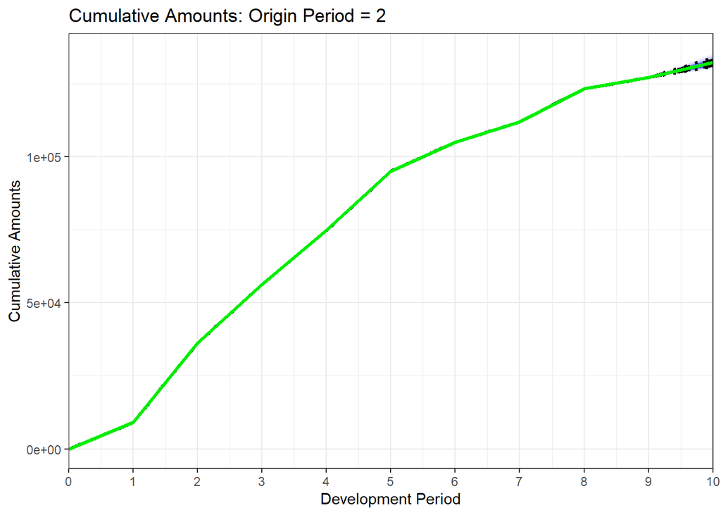

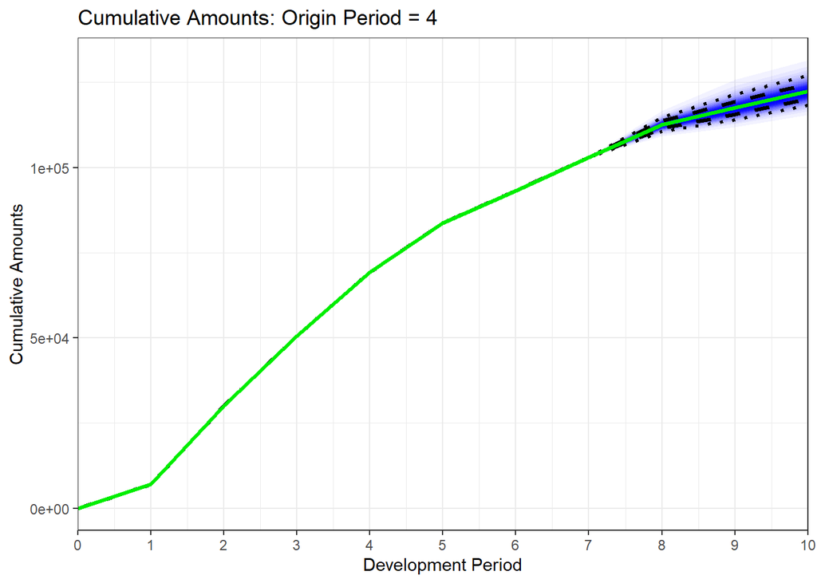

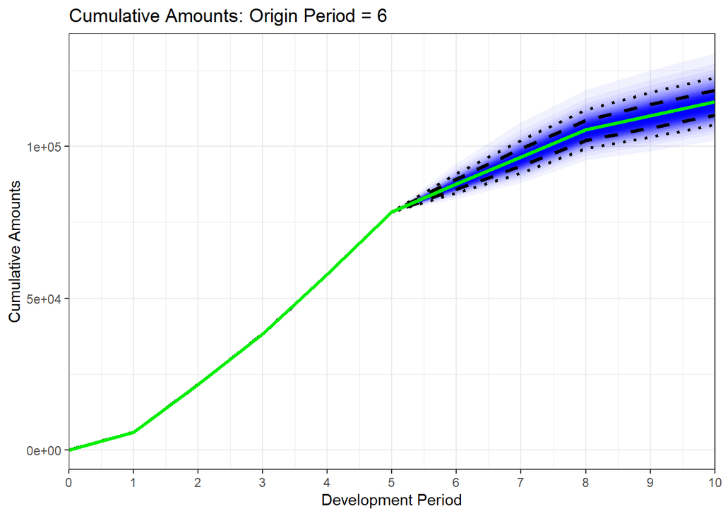

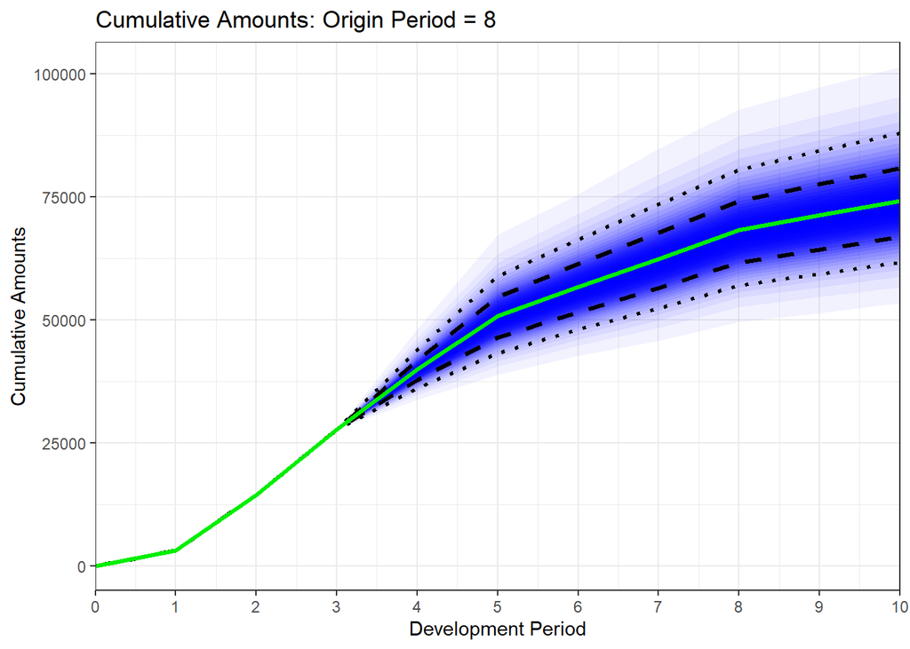

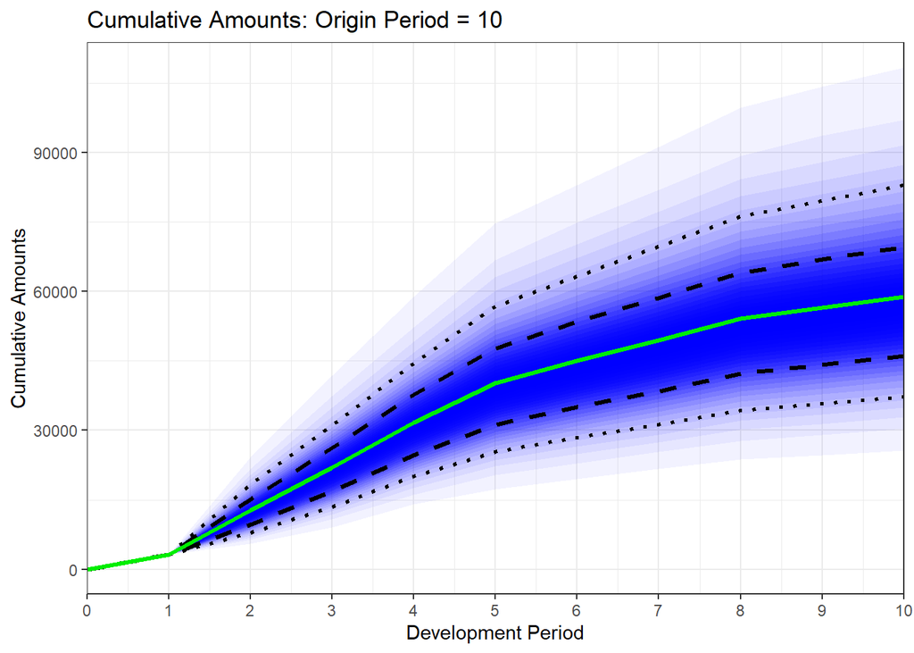

```r
BStrap_Cumulatives <- ODP_Bstrap_Result$Cumulatives

for (yr in seq(2, ncol(BStrap_Cumulatives), by = 2)) {
  print(plotDevelopmentGraph(BStrap_Cumulatives,yr))
}
```

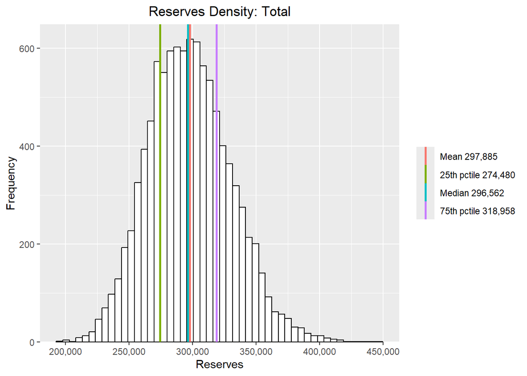

```r
# Histograms - Bootstrap undiscounted reserves
plotHistogram_Total(ODP_Bstrap_Result$TotalReserve)
```

```r
#plotHistogram_by_yr(ODP_Bstrap_Result$Reserves)
```

*Commentary:*

From the reserve development charts we can see that the fan charts no longer suddenly expand at development period 7. The values of sqrtScale have a smoother development, which is evident in the fan charts.